# Multiple Linear Regression on Customer Data

Insofe Lab Session

July 02 , 2017

```r
# Go through the data and understand the attributes to get the info of the variables.
```

Write a code to clear the environment if needed

```r
rm(list=(ls(all=TRUE)))
```

Write a code to set the working directory.

```r
setwd("C:\\insofe\\lab_assignments\\20170702_Batch30_CSE7302c_CustomerData_Assignment")
getwd()
```

```
## [1] "C:/insofe/lab_assignments/20170702_Batch30_CSE7302c_CustomerData_Assignment"
```

Think and load the libraries as and when required in this place only as best practice

```r
library(vegan)
```

```r
library(corrplot)
library(dummies)
library(MASS)
library(car)
library(DMwR)
```

Write a code to read the csv file as “data” as per required

```r
customer_data=read.csv("20170702_Batch30_CSE7302c_CustomerData_Assignment.csv")
```

Write a code to know the names of the attributes

```r
names(customer_data)
```

```
##  [1] "CustomerID"                   "City"
##  [3] "NoOfChildren"                 "MinAgeOfChild"
##  [5] "MaxAgeOfChild"                "Tenure"
##  [7] "FrquncyOfPurchase"            "NoOfUnitsPurchased"
##  [9] "FrequencyOFPlay"              "NoOfGamesPlayed"
## [11] "NoOfGamesBought"              "FavoriteChannelOfTransaction"
## [13] "FavoriteGame"                 "TotalRevenueGenerated"
```

Write a code to find the dimensions of the data

```r
dim(customer_data)
```

```
## [1] 3209   14
```

Write a code to see the head and tail of the dataset atleast 10rows

```r
head(customer_data)
```

```
##   CustomerID City NoOfChildren MinAgeOfChild MaxAgeOfChild Tenure
## 1       1001    1            2             3             8    210
## 2       1002    1            2             3             6    442
## 3       1003    1            4             3             5    424
## 4       1004    1            1             6             6    261
## 5       1005    1            3             6             9    422
## 6       1006    1            2             3             4    378
##   FrquncyOfPurchase NoOfUnitsPurchased FrequencyOFPlay NoOfGamesPlayed
## 1                11                 11            2344             108
## 2                20                 20             245              22
## 3                18                 18            1059             130
## 4                11                  9             365              34
## 5                44                 31            1066             102
## 6                16                 16             228              12
##   NoOfGamesBought FavoriteChannelOfTransaction FavoriteGame
## 1              10                      Uniform      Uniform
## 2               7                     Favorite      Uniform
## 3              18                     Favorite      Uniform
## 4              11                     Favorite      Uniform
## 5              44                      Uniform      Uniform
## 6              16                     Favorite     Favorite
##   TotalRevenueGenerated
## 1                107.51
## 2                382.40
## 3                135.01
## 4                125.00
## 5                335.05
## 6                150.00
```

```r
tail(customer_data)
```

```
##      CustomerID City NoOfChildren MinAgeOfChild MaxAgeOfChild Tenure
## 3204       4204    1            1             4             4    431
## 3205       4205    1            2             4             6    365
## 3206       4206    1            2             2             5    348
## 3207       4207    1            2             5             7    341
## 3208       4208    1            2             6             7    368
## 3209       4209    1            3             2             6    389
##      FrquncyOfPurchase NoOfUnitsPurchased FrequencyOFPlay NoOfGamesPlayed
## 3204                26                 26            1166              72
## 3205                16                 16             827              78
## 3206                20                 20            2933             294
## 3207                16                 13            1250             126
## 3208                18                 14            1364             122
## 3209                25                 17             475             111
##      NoOfGamesBought FavoriteChannelOfTransaction FavoriteGame
## 3204              26                     Favorite      Uniform
## 3205              16                     Favorite      Uniform
## 3206              13                     Favorite      Uniform
## 3207              16                      Uniform      Uniform
## 3208              18                     Favorite      Uniform
## 3209              25                     Favorite      Uniform
##      TotalRevenueGenerated
## 3204                205.00
## 3205                132.50
## 3206                223.23
## 3207                120.00
## 3208                161.50
## 3209                137.50
```

Write a code to see the data types of the attributes

```r
str(customer_data)
```

```
## 'data.frame':    3209 obs. of  14 variables:
##  $ CustomerID                  : int  1001 1002 1003 1004 1005 1006 1007 1008 1009 1010 ...
##  $ City                        : int  1 1 1 1 1 1 1 1 1 2 ...
##  $ NoOfChildren                : int  2 2 4 1 3 2 3 2 4 3 ...
##  $ MinAgeOfChild               : int  3 3 3 6 6 3 8 6 6 5 ...
##  $ MaxAgeOfChild               : int  8 6 5 6 9 4 12 8 9 6 ...
##  $ Tenure                      : int  210 442 424 261 422 378 369 404 420 333 ...
##  $ FrquncyOfPurchase           : int  11 20 18 11 44 16 25 13 20 15 ...
##  $ NoOfUnitsPurchased          : int  11 20 18 9 31 16 15 12 16 15 ...
##  $ FrequencyOFPlay             : int  2344 245 1059 365 1066 228 75 1488 2743 1967 ...
##  $ NoOfGamesPlayed             : int  108 22 130 34 102 12 2 118 163 56 ...
##  $ NoOfGamesBought             : int  10 7 18 11 44 16 25 13 16 15 ...
##  $ FavoriteChannelOfTransaction: Factor w/ 2 levels "Favorite","Uniform": 2 1 1 1 2 1 1 1 2 1 ...
##  $ FavoriteGame                : Factor w/ 3 levels "Favorite","NONE",..: 3 3 3 3 3 1 1 3 3 3 ...
##  $ TotalRevenueGenerated       : num  108 382 135 125 335 ...
```

Write a code to remove the unuseful variables and store the data

```r
customer_data=customer_data[,-c(1)]
```

Write a code to observe the variables and convert them into the required formats

```r
str(customer_data)
```

```
## 'data.frame':    3209 obs. of  13 variables:
##  $ City                        : int  1 1 1 1 1 1 1 1 1 2 ...
##  $ NoOfChildren                : int  2 2 4 1 3 2 3 2 4 3 ...
##  $ MinAgeOfChild               : int  3 3 3 6 6 3 8 6 6 5 ...
##  $ MaxAgeOfChild               : int  8 6 5 6 9 4 12 8 9 6 ...
##  $ Tenure                      : int  210 442 424 261 422 378 369 404 420 333 ...
##  $ FrquncyOfPurchase           : int  11 20 18 11 44 16 25 13 20 15 ...
##  $ NoOfUnitsPurchased          : int  11 20 18 9 31 16 15 12 16 15 ...
##  $ FrequencyOFPlay             : int  2344 245 1059 365 1066 228 75 1488 2743 1967 ...
##  $ NoOfGamesPlayed             : int  108 22 130 34 102 12 2 118 163 56 ...
##  $ NoOfGamesBought             : int  10 7 18 11 44 16 25 13 16 15 ...
##  $ FavoriteChannelOfTransaction: Factor w/ 2 levels "Favorite","Uniform": 2 1 1 1 2 1 1 1 2 1 ...
##  $ FavoriteGame                : Factor w/ 3 levels "Favorite","NONE",..: 3 3 3 3 3 1 1 3 3 3 ...
##  $ TotalRevenueGenerated       : num  108 382 135 125 335 ...
```

```r
cus_data_cat=c("FavoriteChannelOfTransaction","FavoriteGame")

customer_data[,cus_data_cat]=data.frame(apply(customer_data[,cus_data_cat],2,function(x) as.factor(as.character(x))))
```

Check the changes again using str() command

```r
str(customer_data)
```

```
## 'data.frame':    3209 obs. of  13 variables:
##  $ City                        : int  1 1 1 1 1 1 1 1 1 2 ...
##  $ NoOfChildren                : int  2 2 4 1 3 2 3 2 4 3 ...
##  $ MinAgeOfChild               : int  3 3 3 6 6 3 8 6 6 5 ...
##  $ MaxAgeOfChild               : int  8 6 5 6 9 4 12 8 9 6 ...
##  $ Tenure                      : int  210 442 424 261 422 378 369 404 420 333 ...
##  $ FrquncyOfPurchase           : int  11 20 18 11 44 16 25 13 20 15 ...
##  $ NoOfUnitsPurchased          : int  11 20 18 9 31 16 15 12 16 15 ...
##  $ FrequencyOFPlay             : int  2344 245 1059 365 1066 228 75 1488 2743 1967 ...
##  $ NoOfGamesPlayed             : int  108 22 130 34 102 12 2 118 163 56 ...
##  $ NoOfGamesBought             : int  10 7 18 11 44 16 25 13 16 15 ...
##  $ FavoriteChannelOfTransaction: Factor w/ 2 levels "Favorite","Uniform": 2 1 1 1 2 1 1 1 2 1 ...
##  $ FavoriteGame                : Factor w/ 3 levels "Favorite","NONE",..: 3 3 3 3 3 1 1 3 3 3 ...
##  $ TotalRevenueGenerated       : num  108 382 135 125 335 ...
```

```r
names(customer_data)
```

```
##  [1] "City"                         "NoOfChildren"
##  [3] "MinAgeOfChild"                "MaxAgeOfChild"
##  [5] "Tenure"                       "FrquncyOfPurchase"
##  [7] "NoOfUnitsPurchased"           "FrequencyOFPlay"
##  [9] "NoOfGamesPlayed"              "NoOfGamesBought"
## [11] "FavoriteChannelOfTransaction" "FavoriteGame"
## [13] "TotalRevenueGenerated"
```

Write a Code to seperate the target

```r
customer_data_sep_target=customer_data[,-c(13)]
names(customer_data_sep_target)
```

```
##  [1] "City"                         "NoOfChildren"
##  [3] "MinAgeOfChild"                "MaxAgeOfChild"
##  [5] "Tenure"                       "FrquncyOfPurchase"
##  [7] "NoOfUnitsPurchased"           "FrequencyOFPlay"
##  [9] "NoOfGamesPlayed"              "NoOfGamesBought"
## [11] "FavoriteChannelOfTransaction" "FavoriteGame"
```

Write a code to get the numerical attributes out and store them as data_num

```r
cus_data_num=c(setdiff(names(customer_data_sep_target),cus_data_cat))
```

Perform binning on city,No of Children, Minimum age of the child,Maximum age of the child

```r
customer_num = customer_data_sep_target[cus_data_num]
customer_cat = customer_data_sep_target[cus_data_cat]

#library(infotheo)

#customer_num[,1]<- discretize(customer_num[,1], disc="equalfreq",nbins=2)
#customer_num[,2]<- discretize(customer_num[,2], disc="equalfreq",nbins=3)
#customer_num[,3]<- discretize(customer_num[,3], disc="equalfreq",nbins=3)
#customer_num[,4]<- discretize(customer_num[,4], disc="equalfreq",nbins=3)

head(customer_num)
```

```
##   City NoOfChildren MinAgeOfChild MaxAgeOfChild Tenure FrquncyOfPurchase
## 1    1            2             3             8    210                11
## 2    1            2             3             6    442                20
## 3    1            4             3             5    424                18
## 4    1            1             6             6    261                11
## 5    1            3             6             9    422                44
## 6    1            2             3             4    378                16
##   NoOfUnitsPurchased FrequencyOFPlay NoOfGamesPlayed NoOfGamesBought
## 1                 11            2344             108              10
## 2                 20             245              22               7
## 3                 18            1059             130              18
## 4                  9             365              34              11
## 5                 31            1066             102              44
## 6                 16             228              12              16
```

```r
tail(customer_num)
```

```
##      City NoOfChildren MinAgeOfChild MaxAgeOfChild Tenure
## 3204    1            1             4             4    431
## 3205    1            2             4             6    365
## 3206    1            2             2             5    348
## 3207    1            2             5             7    341
## 3208    1            2             6             7    368
## 3209    1            3             2             6    389
##      FrquncyOfPurchase NoOfUnitsPurchased FrequencyOFPlay NoOfGamesPlayed
## 3204                26                 26            1166              72
## 3205                16                 16             827              78
## 3206                20                 20            2933             294
## 3207                16                 13            1250             126
## 3208                18                 14            1364             122
## 3209                25                 17             475             111
##      NoOfGamesBought
## 3204              26
## 3205              16
## 3206              13
## 3207              16
## 3208              18
## 3209              25
```

Write a code for Normalizing the data_num

```r
#customer_num_standardized <- decostand(customer_num,"standardize") # Using Z score method
#summary(customer_num_standardized)
```

Write a code to observe the correlation between the attributes

```r
customer_num_final = cbind(customer_num,TotalRevenueGenerated=customer_data[,c(13)])
cor(customer_num_final)
```

```
##                              City NoOfChildren MinAgeOfChild MaxAgeOfChild
## City                   1.00000000  -0.06535034  0.0098652302  -0.032211132
## NoOfChildren          -0.06535034   1.00000000 -0.1791759583   0.189001961
## MinAgeOfChild          0.00986523  -0.17917596  1.0000000000   0.367127367
## MaxAgeOfChild         -0.03221113   0.18900196  0.3671273667   1.000000000
## Tenure                 0.05223583   0.08534060 -0.0558202691  -0.040329109
## FrquncyOfPurchase     -0.09949866   0.13763028 -0.0175678432  -0.006212834
## NoOfUnitsPurchased    -0.06639564   0.13703962 -0.0061912434  -0.003925588
## FrequencyOFPlay        0.04881790   0.16503572  0.0066897624   0.012095286
## NoOfGamesPlayed        0.01600958   0.21334244  0.0001039156   0.027946580
## NoOfGamesBought       -0.03405549   0.13139836 -0.0077484225  -0.007062492
## TotalRevenueGenerated -0.07111015   0.10736454  0.0247243006   0.005891343
##                            Tenure FrquncyOfPurchase NoOfUnitsPurchased
## City                   0.05223583      -0.099498664       -0.066395644
## NoOfChildren           0.08534060       0.137630281        0.137039620
## MinAgeOfChild         -0.05582027      -0.017567843       -0.006191243
## MaxAgeOfChild         -0.04032911      -0.006212834       -0.003925588
## Tenure                 1.00000000       0.193343704        0.192413092
## FrquncyOfPurchase      0.19334370       1.000000000        0.934130532
## NoOfUnitsPurchased     0.19241309       0.934130532        1.000000000
## FrequencyOFPlay        0.24180938       0.279957433        0.311981695
## NoOfGamesPlayed        0.27369597       0.397566861        0.436149179
## NoOfGamesBought        0.18828481       0.947787464        0.868374420
## TotalRevenueGenerated  0.11643733       0.663327965        0.750379060
##                       FrequencyOFPlay NoOfGamesPlayed NoOfGamesBought
## City                      0.048817898    0.0160095812    -0.034055491
## NoOfChildren              0.165035716    0.2133424389     0.131398358
## MinAgeOfChild             0.006689762    0.0001039156    -0.007748422
## MaxAgeOfChild             0.012095286    0.0279465799    -0.007062492
## Tenure                    0.241809378    0.2736959714     0.188284813
## FrquncyOfPurchase         0.279957433    0.3975668611     0.947787464
## NoOfUnitsPurchased        0.311981695    0.4361491791     0.868374420
## FrequencyOFPlay           1.000000000    0.7402043013     0.286943164
## NoOfGamesPlayed           0.740204301    1.0000000000     0.399178320
## NoOfGamesBought           0.286943164    0.3991783197     1.000000000
## TotalRevenueGenerated     0.233540348    0.2939945843     0.495759123
##                       TotalRevenueGenerated
## City                           -0.071110154
## NoOfChildren                    0.107364537
## MinAgeOfChild                   0.024724301
## MaxAgeOfChild                   0.005891343
## Tenure                          0.116437331
## FrquncyOfPurchase               0.663327965
## NoOfUnitsPurchased              0.750379060
## FrequencyOFPlay                 0.233540348
## NoOfGamesPlayed                 0.293994584
## NoOfGamesBought                 0.495759123
## TotalRevenueGenerated           1.000000000
```

Write a code to plot the corrplot of correlation between the attributes

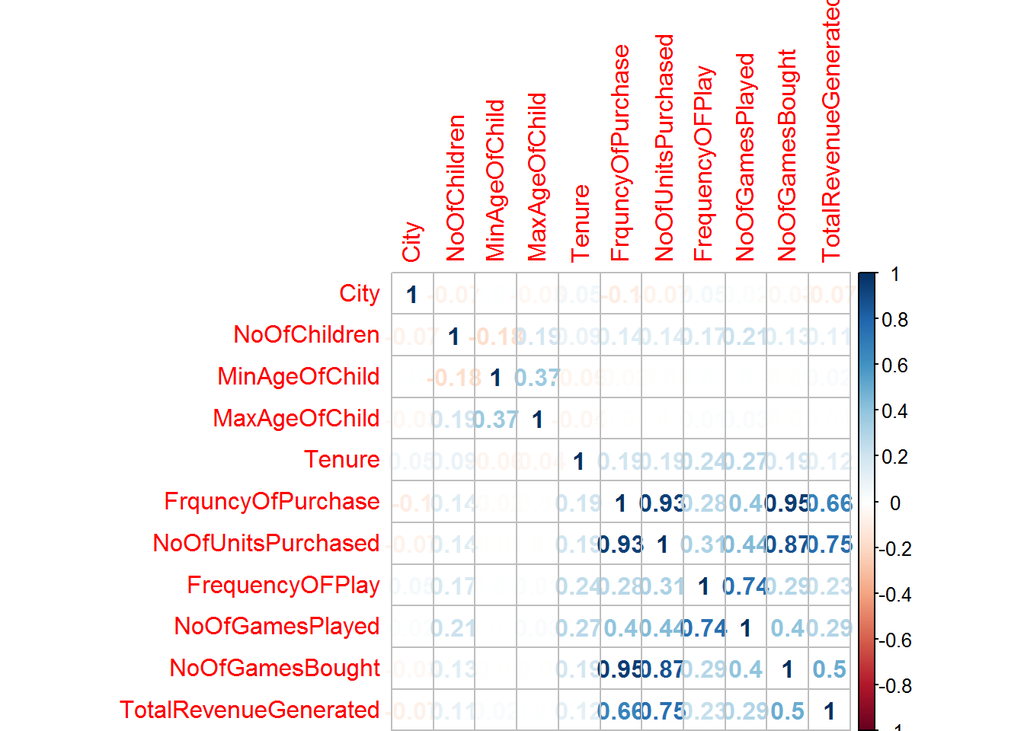

```r
corrplot(cor(customer_num_final), method = "number")
```

```r
names(customer_num_final)
```

```
##  [1] "City"                  "NoOfChildren"
##  [3] "MinAgeOfChild"         "MaxAgeOfChild"
##  [5] "Tenure"                "FrquncyOfPurchase"
##  [7] "NoOfUnitsPurchased"    "FrequencyOFPlay"
##  [9] "NoOfGamesPlayed"       "NoOfGamesBought"
## [11] "TotalRevenueGenerated"
```

Write a code to seperate the categorical attributes

```r
print("Done already")
```

```
## [1] "Done already"
```

Write a code to combine the numerical,categorical data along with the target

```r
customer_num_final_with_cat = cbind(customer_num_final,customer_cat)
names(customer_num_final_with_cat)
```

```
##  [1] "City"                         "NoOfChildren"
##  [3] "MinAgeOfChild"                "MaxAgeOfChild"
##  [5] "Tenure"                       "FrquncyOfPurchase"
##  [7] "NoOfUnitsPurchased"           "FrequencyOFPlay"
##  [9] "NoOfGamesPlayed"              "NoOfGamesBought"
## [11] "TotalRevenueGenerated"        "FavoriteChannelOfTransaction"
## [13] "FavoriteGame"
```

Create Dummy variables for FavoriteChannelOfTransaction and FavoriteGame

```r
#table(customer_num_final_with_cat_target$FavoriteChannelOfTransaction,customer_num_final_with_cat_target$FavoriteGame)

#df_final_dummy1<-dummy(customer_num_final_with_cat_target$FavoriteChannelOfTransaction)
#colnames(df_final_dummy1)=c("FavoriteChannelOfTransaction1","FavoriteChannelOfTransaction2")

#customer_num_final_dum1 <- data.frame(customer_num_final_with_cat_target,df_final_dummy1)
#names(customer_num_final_dum1)


#df_final_dummy2<-dummy(customer_num_final_with_cat_target$FavoriteGame)
#colnames(df_final_dummy2)=c("FavoriteGame1","FavoriteGame2","FavoriteGame3")
#customer_num_final_dum2 <- data.frame(customer_num_final_dum1,df_final_dummy2)
#names(customer_num_final_dum2)

#customer_num_final_with_cat=customer_num_final_with_cat[,-c(10)]
#names(customer_num_final_with_cat)
```

Check for NA values

```r
sum(is.na(customer_num_final_with_cat))
```

```
## [1] 0
```

Write a code to set the seed and comment why it is used.

**Ans** Set seed is used so that we get a random data set that is reproducible.

```r
set.seed(123)
```

Write a code to get the train rows using sample

```r
train_rows <- sample(x = 1:nrow(customer_num_final_with_cat), size = 0.7*nrow(customer_num_final_with_cat))
```

Write a code to get the train and test

```r
train_data <- customer_num_final_with_cat[train_rows, ]

test_data <- customer_num_final_with_cat[-train_rows, ]

head(train_data)
```

```
##      City NoOfChildren MinAgeOfChild MaxAgeOfChild Tenure
## 923     1            1             8             8    231
## 2529    1            1             7             7    337
## 1312    1            6             1            13    373
## 2831    1            2             3             6    195
## 3015    1            3             4            11    383
## 146     2            1             6             6    384
##      FrquncyOfPurchase NoOfUnitsPurchased FrequencyOFPlay NoOfGamesPlayed
## 923                 16                 16             520              50
## 2529                 8                  7            3015             142
## 1312                16                 16             601              66
## 2831                18                 14              12               3
## 3015                16                 16             502              82
## 146                 11                 11             531              48
##      NoOfGamesBought TotalRevenueGenerated FavoriteChannelOfTransaction
## 923               16                127.50                     Favorite
## 2529               4                106.21                     Favorite
## 1312              13                156.47                     Favorite
## 2831              18                105.00                     Favorite
## 3015              14                179.98                     Favorite
## 146               11                178.13                     Favorite
##      FavoriteGame
## 923       Uniform
## 2529      Uniform
## 1312      Uniform
## 2831     Favorite
## 3015      Uniform
## 146       Uniform
```

```r
head(test_data)
```

```
##    City NoOfChildren MinAgeOfChild MaxAgeOfChild Tenure FrquncyOfPurchase
## 1     1            2             3             8    210                11
## 4     1            1             6             6    261                11
## 11    1            1             5             5    323                 9
## 13    1            1             4             4    381                15
## 14    1            4             5             7    399                36
## 15    1            2             4             7    444                14
##    NoOfUnitsPurchased FrequencyOFPlay NoOfGamesPlayed NoOfGamesBought
## 1                  11            2344             108              10
## 4                   9             365              34              11
## 11                  9             218               1               3
## 13                 15             267              51              15
## 14                 24            6411             355              36
## 15                 14            2804             133              14
##    TotalRevenueGenerated FavoriteChannelOfTransaction FavoriteGame
## 1                 107.51                      Uniform      Uniform
## 4                 125.00                     Favorite      Uniform
## 11                211.92                     Favorite     Favorite
## 13                167.50                     Favorite      Uniform
## 14                202.50                     Favorite      Uniform
## 15                105.50                      Uniform      Uniform
```

```r
#plot(customer_num_final_dum$TotalRevenueGenerated, customer_num_final_dum$NoOfChildren, xlab = #"TotalRevenueGenerated", ylab = "NoOfChildren", main = "TotalRevenueGenerated vs NoOfChildren")
```

Write a code to form a linear regression model

```r
model_basic <- lm(formula = TotalRevenueGenerated~. , data = train_data)
model_basic
```

```
##
## Call:
## lm(formula = TotalRevenueGenerated ~ ., data = train_data)
##
## Coefficients:
##                         (Intercept)                                 City
##                           29.865350                             8.885112
##                        NoOfChildren                        MinAgeOfChild
##                            2.027603                             0.913805
##                       MaxAgeOfChild                               Tenure
##                           -0.094661                            -0.019802
##                   FrquncyOfPurchase                   NoOfUnitsPurchased
##                           10.707275                             9.295610
##                     FrequencyOFPlay                      NoOfGamesPlayed
##                            0.002229                            -0.004392
##                     NoOfGamesBought  FavoriteChannelOfTransactionUniform
##                          -11.814371                           -15.531519
##                    FavoriteGameNONE                  FavoriteGameUniform
##                           -4.645592                            -9.709446
```

Write a code to plot the model

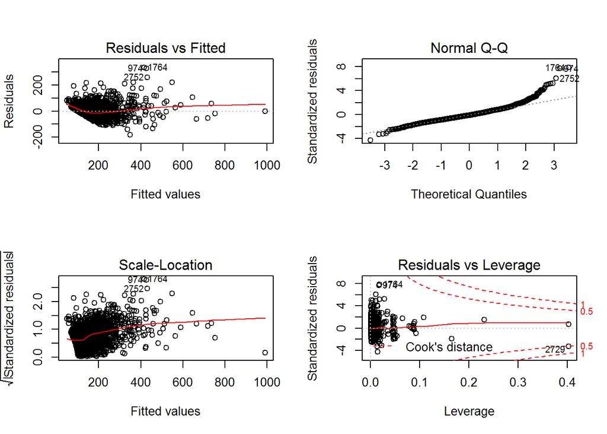

```r
par(mfrow = c(2,2))

plot(model_basic)
```

Write a code to check the summary of the model

```r
summary(model_basic)
```

```
##
## Call:
## lm(formula = TotalRevenueGenerated ~ ., data = train_data)
##
## Residuals:
##     Min      1Q  Median      3Q     Max
## -181.78  -26.40   -4.12   22.06  333.99
##
## Coefficients:
##                                       Estimate Std. Error t value Pr(>|t|)
## (Intercept)                          2.987e+01  7.181e+00   4.159 3.32e-05
## City                                 8.885e+00  2.982e+00   2.980  0.00292
## NoOfChildren                         2.028e+00  9.466e-01   2.142  0.03230
## MinAgeOfChild                        9.138e-01  2.799e-01   3.265  0.00111
## MaxAgeOfChild                       -9.466e-02  1.205e-01  -0.786  0.43204
## Tenure                              -1.980e-02  1.054e-02  -1.878  0.06050
## FrquncyOfPurchase                    1.071e+01  5.044e-01  21.228  < 2e-16
## NoOfUnitsPurchased                   9.296e+00  3.674e-01  25.300  < 2e-16
## FrequencyOFPlay                      2.229e-03  7.073e-04   3.152  0.00164
## NoOfGamesPlayed                     -4.392e-03  1.596e-02  -0.275  0.78315
## NoOfGamesBought                     -1.181e+01  3.523e-01 -33.538  < 2e-16
## FavoriteChannelOfTransactionUniform -1.553e+01  2.434e+00  -6.381 2.13e-10
## FavoriteGameNONE                    -4.646e+00  1.036e+01  -0.449  0.65383
## FavoriteGameUniform                 -9.709e+00  4.915e+00  -1.975  0.04836
##
## (Intercept)                         ***
## City                                **
## NoOfChildren                        *
## MinAgeOfChild                       **
## MaxAgeOfChild
## Tenure                              .
## FrquncyOfPurchase                   ***
## NoOfUnitsPurchased                  ***
## FrequencyOFPlay                     **
## NoOfGamesPlayed
## NoOfGamesBought                     ***
## FavoriteChannelOfTransactionUniform ***
## FavoriteGameNONE
## FavoriteGameUniform                 *
## ---
## Signif. codes:  0 '***' 0.001 '**' 0.01 '*' 0.05 '.' 0.1 ' ' 1
##
## Residual standard error: 42.89 on 2232 degrees of freedom
## Multiple R-squared:  0.741,  Adjusted R-squared:  0.7395
## F-statistic: 491.3 on 13 and 2232 DF,  p-value: < 2.2e-16
```

Write a code to predict the value of the target on the linear model

```r
preds_model_basic <- predict(model_basic, test_data[, !(names(test_data) %in% c("TotalRevenueGenerated"))])
preds_model_basic
```

[output not shown]

[output cut: 221 more lines]

[output not shown]

Write a code to use stepAIC

```r
model_aic <- stepAIC(model_basic, direction = "both")
```

```
## Start:  AIC=16897.76
## TotalRevenueGenerated ~ City + NoOfChildren + MinAgeOfChild +
##     MaxAgeOfChild + Tenure + FrquncyOfPurchase + NoOfUnitsPurchased +
##     FrequencyOFPlay + NoOfGamesPlayed + NoOfGamesBought + FavoriteChannelOfTransaction +
##     FavoriteGame
##
##                                Df Sum of Sq     RSS   AIC
## - NoOfGamesPlayed               1       139 4106018 16896
## - MaxAgeOfChild                 1      1136 4107015 16896
## <none>                                      4105879 16898
## - FavoriteGame                  2      7546 4113425 16898
## - Tenure                        1      6489 4112367 16899
## - NoOfChildren                  1      8440 4114319 16900
## - City                          1     16332 4122211 16905
## - FrequencyOFPlay               1     18276 4124154 16906
## - MinAgeOfChild                 1     19610 4125488 16907
## - FavoriteChannelOfTransaction  1     74913 4180792 16936
## - FrquncyOfPurchase             1    828932 4934810 17309
## - NoOfUnitsPurchased            1   1177467 5283345 17462
## - NoOfGamesBought               1   2069160 6175039 17812
##
## Step:  AIC=16895.84
## TotalRevenueGenerated ~ City + NoOfChildren + MinAgeOfChild +
##     MaxAgeOfChild + Tenure + FrquncyOfPurchase + NoOfUnitsPurchased +
##     FrequencyOFPlay + NoOfGamesBought + FavoriteChannelOfTransaction +
##     FavoriteGame
##
##                                Df Sum of Sq     RSS   AIC
## - MaxAgeOfChild                 1      1131 4107149 16895
## <none>                                      4106018 16896
## - FavoriteGame                  2      7738 4113756 16896
## - Tenure                        1      6760 4112778 16898
## + NoOfGamesPlayed               1       139 4105879 16898
## - NoOfChildren                  1      8305 4114323 16898
## - City                          1     16322 4122340 16903
## - MinAgeOfChild                 1     19604 4125622 16905
## - FrequencyOFPlay               1     27927 4133945 16909
## - FavoriteChannelOfTransaction  1     75316 4181334 16935
## - FrquncyOfPurchase             1    839361 4945379 17312
## - NoOfUnitsPurchased            1   1205158 5311176 17472
## - NoOfGamesBought               1   2096862 6202880 17820
##
## Step:  AIC=16894.46
## TotalRevenueGenerated ~ City + NoOfChildren + MinAgeOfChild +
##     Tenure + FrquncyOfPurchase + NoOfUnitsPurchased + FrequencyOFPlay +
##     NoOfGamesBought + FavoriteChannelOfTransaction + FavoriteGame
##
##                                Df Sum of Sq     RSS   AIC
## <none>                                      4107149 16895
## - FavoriteGame                  2      7902 4115051 16895
## + MaxAgeOfChild                 1      1131 4106018 16896
## - Tenure                        1      6568 4113717 16896
## + NoOfGamesPlayed               1       134 4107015 16896
## - NoOfChildren                  1      7238 4114387 16896
## - City                          1     16474 4123623 16901
## - MinAgeOfChild                 1     19298 4126446 16903
## - FrequencyOFPlay               1     28255 4135404 16908
## - FavoriteChannelOfTransaction  1     75467 4182616 16933
## - FrquncyOfPurchase             1    839357 4946505 17310
## - NoOfUnitsPurchased            1   1205909 5313058 17471
## - NoOfGamesBought               1   2096789 6203937 17819
```

```r
summary(model_aic)
```

```
##
## Call:
## lm(formula = TotalRevenueGenerated ~ City + NoOfChildren + MinAgeOfChild +
##     Tenure + FrquncyOfPurchase + NoOfUnitsPurchased + FrequencyOFPlay +
##     NoOfGamesBought + FavoriteChannelOfTransaction + FavoriteGame,
##     data = train_data)
##
## Residuals:
##     Min      1Q  Median      3Q     Max
## -181.85  -26.50   -3.99   22.21  333.11
##
## Coefficients:
##                                       Estimate Std. Error t value Pr(>|t|)
## (Intercept)                          3.013e+01  7.136e+00   4.222 2.52e-05
## City                                 8.922e+00  2.981e+00   2.993  0.00279
## NoOfChildren                         1.790e+00  9.020e-01   1.984  0.04735
## MinAgeOfChild                        8.202e-01  2.532e-01   3.240  0.00121
## Tenure                              -1.980e-02  1.048e-02  -1.890  0.05887
## FrquncyOfPurchase                    1.072e+01  5.018e-01  21.367  < 2e-16
## NoOfUnitsPurchased                   9.282e+00  3.624e-01  25.611  < 2e-16
## FrequencyOFPlay                      2.115e-03  5.396e-04   3.920 9.11e-05
## NoOfGamesBought                     -1.182e+01  3.501e-01 -33.771  < 2e-16
## FavoriteChannelOfTransactionUniform -1.557e+01  2.431e+00  -6.407 1.81e-10
## FavoriteGameNONE                    -4.618e+00  1.035e+01  -0.446  0.65567
## FavoriteGameUniform                 -9.893e+00  4.901e+00  -2.018  0.04367
##
## (Intercept)                         ***
## City                                **
## NoOfChildren                        *
## MinAgeOfChild                       **
## Tenure                              .
## FrquncyOfPurchase                   ***
## NoOfUnitsPurchased                  ***
## FrequencyOFPlay                     ***
## NoOfGamesBought                     ***
## FavoriteChannelOfTransactionUniform ***
## FavoriteGameNONE
## FavoriteGameUniform                 *
## ---
## Signif. codes:  0 '***' 0.001 '**' 0.01 '*' 0.05 '.' 0.1 ' ' 1
##
## Residual standard error: 42.88 on 2234 degrees of freedom
## Multiple R-squared:  0.741,  Adjusted R-squared:  0.7397
## F-statistic: 580.9 on 11 and 2234 DF,  p-value: < 2.2e-16
```

Write a code to predict it on stepAIC

```r
preds_model_aic <- predict(model_aic, test_data[, !(names(test_data) %in% c("TotalRevenueGenerated"))])
preds_model_aic
```

[output not shown]

[output cut: 221 more lines]

[output not shown]

Write a code to check the multicollinearity in the lm model

```r
vif(model_basic)
```

```
##                                   GVIF Df GVIF^(1/(2*Df))
## City                          1.077669  1        1.038108
## NoOfChildren                  1.184375  1        1.088290
## MinAgeOfChild                 1.273206  1        1.128364
## MaxAgeOfChild                 1.270693  1        1.127250
## Tenure                        1.101558  1        1.049551
## FrquncyOfPurchase            23.358579  1        4.833071
## NoOfUnitsPurchased            9.110419  1        3.018347
## FrequencyOFPlay               2.046243  1        1.430470
## NoOfGamesPlayed               2.409533  1        1.552267
## NoOfGamesBought              12.100235  1        3.478539
## FavoriteChannelOfTransaction  1.085359  1        1.041805
## FavoriteGame                  1.072610  2        1.017678
```

Write a code to check the plots of the models

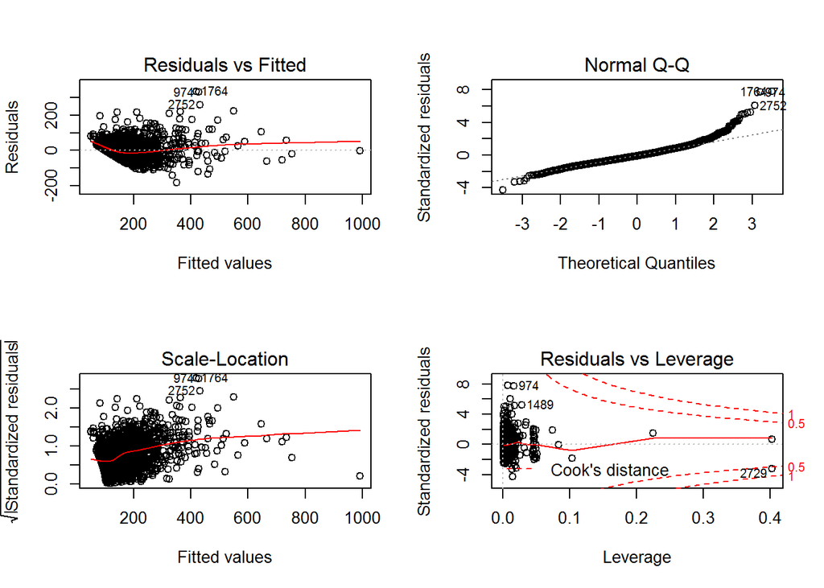

```r
par(mfrow = c(2,2))

plot(model_aic)
```

Write a code to check the multicollinearity problem

```r
vif(model_aic)
```

```
##                                   GVIF Df GVIF^(1/(2*Df))
## City                          1.077343  1        1.037952
## NoOfChildren                  1.075963  1        1.037286
## MinAgeOfChild                 1.042444  1        1.021001
## Tenure                        1.088261  1        1.043198
## FrquncyOfPurchase            23.127823  1        4.809140
## NoOfUnitsPurchased            8.868931  1        2.978075
## FrequencyOFPlay               1.191378  1        1.091503
## NoOfGamesBought              11.961376  1        3.458522
## FavoriteChannelOfTransaction  1.083385  1        1.040858
## FavoriteGame                  1.065795  2        1.016058
```

Write a code to evaluate the error in the prediction of AIC

```r
regr.eval(test_data$TotalRevenueGenerated, preds_model_aic)
```

```
##          mae          mse         rmse         mape
##   31.9655908 2026.4851645   45.0164988    0.1888975
```

Write a code to evaluate the error on the prediction of Linear Regression

```r
regr.eval(test_data$TotalRevenueGenerated, preds_model_basic)
```

```
##          mae          mse         rmse         mape
##   31.9459866 2021.1599577   44.9573126    0.1888768
```